# Images

SimpleITK conventions:

- Image access is in x,y,z order, image.GetPixel(x,y,z) or image[x,y,z], with zero based indexing.
- If the output of an ITK filter has non-zero starting index, then the index will be set to 0, and the origin adjusted accordingly.

The unique feature of SimpleITK (derived from ITK) as a toolkit for image manipulation and analysis is that it views **images as physical objects occupying a bounded region in physical space**. In addition images can have different spacing between pixels along each axis, and the axes are not necessarily orthogonal. The following figure illustrates these concepts.

[figure not shown]

### Pixel Types

The pixel type is represented as an enumerated type. The following is a table of the enumerated list.

| sitkUInt8 | Unsigned 8 bit integer |
| --- | --- |
| sitkInt8 | Signed 8 bit integer |
| sitkUInt16 | Unsigned 16 bit integer |
| sitkInt16 | Signed 16 bit integer |
| sitkUInt32 | Unsigned 32 bit integer |
| sitkInt32 | Signed 32 bit integer |
| sitkUInt64 | Unsigned 64 bit integer |
| sitkInt64 | Signed 64 bit integer |
| sitkFloat32 | 32 bit float |
| sitkFloat64 | 64 bit float |
| sitkComplexFloat32 | complex number of 32 bit float |
| sitkComplexFloat64 | complex number of 64 bit float |
| sitkVectorUInt8 | Multi-component of unsigned 8 bit integer |
| sitkVectorInt8 | Multi-component of signed 8 bit integer |
| sitkVectorUInt16 | Multi-component of unsigned 16 bit integer |
| sitkVectorInt16 | Multi-component of signed 16 bit integer |
| sitkVectorUInt32 | Multi-component of unsigned 32 bit integer |
| sitkVectorInt32 | Multi-component of signed 32 bit integer |
| sitkVectorUInt64 | Multi-component of unsigned 64 bit integer |
| sitkVectorInt64 | Multi-component of signed 64 bit integer |
| sitkVectorFloat32 | Multi-component of 32 bit float |
| sitkVectorFloat64 | Multi-component of 64 bit float |
| sitkLabelUInt8 | RLE label of unsigned 8 bit integers |
| sitkLabelUInt16 | RLE label of unsigned 16 bit integers |
| sitkLabelUInt32 | RLE label of unsigned 32 bit integers |
| sitkLabelUInt64 | RLE label of unsigned 64 bit integers |

There is also `sitkUnknown`, which is used for undefined or erroneous pixel ID's. It has a value of -1.

The 64-bit integer types are not available on all distributions. When not available the value is `sitkUnknown`.

```python
import SimpleITK as sitk

from __future__ import print_function

import matplotlib.pyplot as plt
%matplotlib inline
import numpy as np

from IPython.html.widgets import interact, fixed
import os

OUTPUT_DIR = 'Output'

# Utility method that either downloads data from the MIDAS repository or
# if already downloaded returns the file name for reading from disk (cached data).
from downloaddata import fetch_data as fdata
```

```
:0: FutureWarning: IPython widgets are experimental and may change in the future.
```

## Load your first image and display it

```
Fetching SimpleITK.jpg
```

[figure not shown]

```python
logo = sitk.ReadImage(fdata('SimpleITK.jpg'))

plt.imshow(sitk.GetArrayFromImage(logo))
plt.axis('off');
```

## Image Construction

There are a variety of ways to create an image.

The following components are required for a complete definition of an image:

1. Pixel type [fixed on creation, no default]: unsigned 32 bit integer, sitkVectorUInt8, etc., see list above.
2. Sizes [fixed on creation, no default]: number of pixels/voxels in each dimension. This quantity implicitly defines the image dimension.
3. Origin [default is zero]: coordinates of the pixel/voxel with index (0,0,0) in physical units (i.e. mm).
4. Spacing [default is one]: Distance between adjacent pixels/voxels in each dimension given in physical units.
5. Direction matrix [default is identity]: mapping, rotation, between direction of the pixel/voxel axes and physical directions.

The initial pixel/voxel values are well defined - zero.

```python
image_3D = sitk.Image(256, 128, 64, sitk.sitkInt16)
image_2D = sitk.Image(64, 64, sitk.sitkFloat32)
image_2D = sitk.Image([32,32], sitk.sitkUInt32)
image_RGB = sitk.Image([128,64], sitk.sitkVectorUInt8, 3)
```

## Basic Image Attributes

You can change the image origin, spacing and direction. Making such changes to an image already containing data should be done cautiosly.

```python
image_3D.SetOrigin((78.0, 76.0, 77.0))
image_3D.SetSpacing([0.5,0.5,3.0])

print(image_3D.GetOrigin())
print(image_3D.GetSize())
print(image_3D.GetSpacing())
print(image_3D.GetDirection())
```

```
(78.0, 76.0, 77.0)
(256, 128, 64)
(0.5, 0.5, 3.0)
(1.0, 0.0, 0.0, 0.0, 1.0, 0.0, 0.0, 0.0, 1.0)
```

Image dimension queries:

```python
print(image_3D.GetDimension())
print(image_3D.GetWidth())
print(image_3D.GetHeight())
print(image_3D.GetDepth())
```

```
3
256
128
64
```

What is the depth of a 2D image?

```python
print(image_2D.GetSize())
print(image_2D.GetDepth())
```

```
(32, 32)
0
```

Pixel/voxel type queries:

```python
print(image_3D.GetPixelIDValue())
print(image_3D.GetPixelIDTypeAsString())
print(image_3D.GetNumberOfComponentsPerPixel())
```

```
2
16-bit signed integer
1
```

What is the dimension and size of a Vector image and its data?

```python
print(image_RGB.GetDimension())
print(image_RGB.GetSize())
print(image_RGB.GetNumberOfComponentsPerPixel())
```

```
2
(128, 64)
3
```

## Accessing Pixels and Slicing

The Image class's member functions `GetPixel` and `SetPixel` provide an ITK-like interface for pixel access.

```python
help(image_3D.GetPixel)
```

```
Help on method GetPixel in module SimpleITK.SimpleITK:

GetPixel(self, *idx) method of SimpleITK.SimpleITK.Image instance
    Returns the value of a pixel.

    This method takes 2 parameters in 2D: the x and y index,
    and 3 parameters in 3D: the x, y and z index.
```

```python
print(image_3D.GetPixel(0, 0, 0))
image_3D.SetPixel(0, 0, 0, 1)
print(image_3D.GetPixel(0, 0, 0))

# This can also be done using pythonic notation.
print(image_3D[0,0,1])
image_3D[0,0,1] = 2
print(image_3D[0,0,1])
```

```
0
1
0
2
```

Slicing of SimpleITK images returns a copy of the image data.

This is similar to slicing Python lists and differs from the "view" returned by slicing numpy arrays.

[figure not shown]

```python
# Brute force subsampling
logo_subsampled = logo[::2,::2]

# Get the sub-image containing the word Simple
simple = logo[0:115,:]

# Get the sub-image containing the word Simple and flip it
simple_flipped = logo[115:0:-1,:]

n = 4

plt.subplot(n,1,1)
plt.imshow(sitk.GetArrayFromImage(logo))
plt.axis('off');

plt.subplot(n,1,2)
plt.imshow(sitk.GetArrayFromImage(logo_subsampled))
plt.axis('off');

plt.subplot(n,1,3)
plt.imshow(sitk.GetArrayFromImage(simple))
plt.axis('off')

plt.subplot(n,1,4)
plt.imshow(sitk.GetArrayFromImage(simple_flipped))
plt.axis('off');
```

Draw a square on top of the logo image: After running this cell, uncomment "Version 3" and see its effect.

[figure not shown]

```python
# Version 0: get the numpy array and assign the value via broadcast - later on you will need to construct
# a new image from the array
logo_pixels = sitk.GetArrayFromImage(logo)
logo_pixels[0:10,0:10] = [0,255,0]

# Version 1: generates an error, the image slicing returns a new image and you cannot assign a value to an image
#logo[0:10,0:10] = [255,0,0]

# Version 2: image slicing returns a new image, so all assignments here will not have any effect on the original
# 'logo' image
logo_subimage = logo[0:10, 0:10]
for x in range(0,10):
    for y in range(0,10):
        logo_subimage[x,y] = [255,0,0]

# Version 3: modify the original image, iterate and assing a value to each pixel
#for x in range(0,10):
#    for y in range(0,10):
#        logo[x,y] = [255,0,0]


plt.subplot(2,1,1)
plt.imshow(sitk.GetArrayFromImage(logo))
plt.axis('off')

plt.subplot(2,1,2)
plt.imshow(logo_pixels)
plt.axis('off');
```

## Conversion between numpy and SimpleITK

SimpleITK and numpy indexing access is in opposite order!

SimpleITK: image[x,y,z]  
numpy: image_numpy_array[z,y,x]

### From SimpleITK to numpy

```python
nda = sitk.GetArrayFromImage(image_3D)
print(image_3D.GetSize())
print(nda.shape)

nda = sitk.GetArrayFromImage(image_RGB)
print(image_RGB.GetSize())
print(nda.shape)
```

```
(256, 128, 64)
(64, 128, 256)
(128, 64)
(64, 128, 3)
```

### From numpy to SimpleITK

Remember to to set the image's origin, spacing, and possibly direction cosine matrix. The default values may not match the physical dimensions of your image.

```python
nda = np.zeros((10,20,3))

        #if this is supposed to be a 3D gray scale image [x=3, y=20, z=10]
img = sitk.GetImageFromArray(nda)
print(img.GetSize())

      #if this is supposed to be a 2D color image [x=20,y=10]
img = sitk.GetImageFromArray(nda, isVector=True)
print(img.GetSize())
```

```
(3, 20, 10)
(20, 10)
```

### Image operations

SimpleITK supports basic arithmetic operations between images, **taking into account their physical space**.

Repeatedly run this cell. Fix the error (comment out the SetDirection, then SetSpacing). Why doesn't the SetOrigin line cause a problem? How close do two physical attributes need to be in order to be considered equivalent?

```python
img1 = sitk.Image(24,24, sitk.sitkUInt8)
img1[0,0] = 0

img2 = sitk.Image(img1.GetSize(), sitk.sitkUInt8)
img2.SetDirection([0,1,0.5,0.5])
img2.SetSpacing([0.5,0.8])
img2.SetOrigin([0.000001,0.000001])
img2[0,0] = 255

img3 = img1 + img2
print(img3[0,0])
```

[output not shown]

## Reading and Writing

SimpleITK can read and write images stored in a single file, or a set of files (e.g. DICOM series).

Images stored in the DICOM format have a meta-data dictionary associated with them. When a DICOM series is read as a single image, the meta information is lost as SimpleITK does not consolidate the information from the separate file dictionaries. If you need the meta-data you can access the dictionary for each of the files by reading each file seperately.

Read an image in jpg format and write it as png and bmp. File format deducded from file extension. Appropriate pixel type is also set - you can override this and force the pixel type of your choice

```python
img = sitk.ReadImage(fdata('SimpleITK.jpg'))
print(img.GetPixelIDTypeAsString())

          #write as png and bmp
sitk.WriteImage(img, os.path.join(OUTPUT_DIR, 'SimpleITK.png'))
sitk.WriteImage(img, os.path.join(OUTPUT_DIR, 'SimpleITK.bmp'))
```

```
Fetching SimpleITK.jpg
vector of 8-bit unsigned integer
```

Read an image in jpg format and cast the pixel type according to user selection.

```
Fetching SimpleITK.jpg
vector of 8-bit unsigned integer
(255L, 255L, 255L)
```

[figure not shown]

```python
      # Several pixel types, some make sense in this case (vector types) and some are just to show
      # that the user's choice will force the pixel type even when it doesn't make sense.
pixel_types = { 'sitkUInt8': sitk.sitkUInt8,
                'sitkUInt16' : sitk.sitkUInt16,
                'sitkFloat64' : sitk.sitkFloat64,
                'sitkVectorUInt8' : sitk.sitkVectorUInt8,
                'sitkVectorUInt16' : sitk.sitkVectorUInt16,
                'sitkVectorFloat64' : sitk.sitkVectorFloat64}

def pixel_type_dropdown_callback(pixel_type, pixel_types_dict):
                         #specify the file location and the pixel type which we want
    img = sitk.ReadImage(fdata('SimpleITK.jpg'), pixel_types_dict[pixel_type])

    print(img.GetPixelIDTypeAsString())
    print(img[0,0])
    plt.imshow(sitk.GetArrayFromImage(img))
    plt.axis('off')

interact(pixel_type_dropdown_callback, pixel_type=pixel_types.keys(), pixel_types_dict=fixed(pixel_types));
```

Read a DICOM series and write it as a single mha file

```python
data_directory = os.path.dirname(fdata("CIRS057A_MR_CT_DICOM/readme.txt"))
series_ID = '1.2.840.113619.2.290.3.3233817346.783.1399004564.515'

# Get the list of files belonging to a specific series ID.
reader = sitk.ImageSeriesReader()
# Use the functional interface to read the image series.
original_image = sitk.ReadImage(reader.GetGDCMSeriesFileNames(data_directory, series_ID))

# Write the image.
output_file_name_3D = os.path.join(OUTPUT_DIR, '3DImage.mha')
sitk.WriteImage(original_image, output_file_name_3D)

# Read it back again.
written_image = sitk.ReadImage(output_file_name_3D)

# Check that the original and written image are the same.
statistics_image_filter = sitk.StatisticsImageFilter()
statistics_image_filter.Execute(original_image - written_image)

   #check that the original and written files are the same
print('Max, Min differences are : {0}, {1}'.format(statistics_image_filter.GetMaximum(), statistics_image_filter.GetMinimum()))
```

```
Fetching CIRS057A_MR_CT_DICOM/readme.txt
Max, Min differences are : 0.0, 0.0
```

Write an image series as jpg. The WriteImage function receives a volume and a list of images names and writes the volume according to the z axis. For a displayable result we need to rescale the image intensities (default is [0,255]) and the jpg format requires that we cast to UInt8.

```python
sitk.WriteImage(sitk.Cast(sitk.RescaleIntensity(written_image), sitk.sitkUInt8),
                [os.path.join(OUTPUT_DIR,'slice{0:03d}.jpg'.format(i)) for i in range(written_image.GetSize()[2])])
```

Select a specific DICOM series from a directory and only then load user selection.

```python
data_directory = os.path.dirname(fdata("CIRS057A_MR_CT_DICOM/readme.txt"))
            # Global variable 'selected_series' is updated by the interact function
selected_series = ''
def DICOM_series_dropdown_callback(series_to_load, series_dictionary):
    global selected_series
               # Print some information about the series from the meta-data dictionary
              # DICOM standard part 6, Data Dictionary: http://medical.nema.org/medical/dicom/current/output/pdf/part06.pdf
    img = sitk.ReadImage(series_dictionary[series_to_load][0])
    tags_to_print = {'0010|0010': 'Patient name: ',
                     '0008|0060' : 'Modality: ',
                     '0008|0021' : 'Series date: ',
                     '0008|0080' : 'Institution name: ',
                     '0008|1050' : 'Performing physician\'s name: '}
    for tag in tags_to_print:
        try:
            print(tags_to_print[tag] + img.GetMetaData(tag))
        except: # Ignore if the tag isn't in the dictionary
            pass
    selected_series = series_to_load

             # Directory contains multiple DICOM studies/series, store
             # in dictionary with key being the seriesID
reader = sitk.ImageSeriesReader()
series_file_names = {}
series_IDs = reader.GetGDCMSeriesIDs(data_directory)
            # Check that we have at least one series
if series_IDs:
    for series in series_IDs:
        series_file_names[series] = reader.GetGDCMSeriesFileNames(data_directory, series)

    interact(DICOM_series_dropdown_callback, series_to_load=series_IDs, series_dictionary=fixed(series_file_names));
else:
    print('Data directory does not contain any DICOM series.')
```

```
Performing physician's name:
Series date: 20140502
Patient name: test
Institution name: Childrens National Medical Ctr
Modality: CT
```

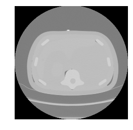

```python
reader.SetFileNames(series_file_names[selected_series])
img = reader.Execute()
npa = sitk.GetArrayFromImage(img)
        # Display the image slice from the middle of the stack, z axis
z = img.GetDepth()/2
plt.imshow(sitk.GetArrayFromImage(img)[z,:,:], cmap=plt.cm.Greys_r)
plt.axis('off');
```

## Image Display

While SimpleITK does not do visualization, it does contain a built in `Show` method. This function writes the image out to disk and than launches a program for visualization. By default it is configured to use [ImageJ](http://imagej.nih.gov/ij/), because it readily supports all the image types which SimpleITK has and loads very quickly. However, it's easily customizable by setting enviroment variables:

- SITK_SHOW_COMMAND: Viewer to use ([ITK-SNAP](http://www.itksnap.org), 3D Slicer...)
- SITK_SHOW_COLOR_COMMAND: Viewer to use when displaying color images.
- SITK_SHOW_3D_COMMAND: Viewer to use for 3D images.

```python
sitk.Show?
```

By converting into a numpy array, matplotlib can be used for visualization for integration into the scientifc python enviroment. This is good for illustrative purposes, but is problematic when working with images that have a high dynamic range or non-isotropic spacing - most 3D medical images.

When working with medical images it is recommended to visualize them using dedicated software such as the freely available 3D Slicer or ITK-SNAP.

```
Fetching training_001_mr_T1.mha
```

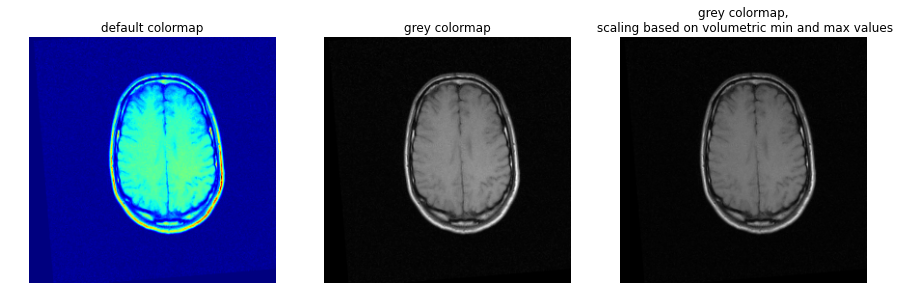

```python
mr_image = sitk.ReadImage(fdata('training_001_mr_T1.mha'))
npa = sitk.GetArrayFromImage(mr_image)

        # Display the image slice from the middle of the stack, z axis
z = mr_image.GetDepth()/2
npa_zslice = sitk.GetArrayFromImage(mr_image)[z,:,:]

   # Three plots displaying the same data, how do we deal with the high dynamic range?
fig = plt.figure()
fig.set_size_inches(15,30)

fig.add_subplot(1,3,1)
plt.imshow(npa_zslice)
plt.title('default colormap')
plt.axis('off')

fig.add_subplot(1,3,2)
plt.imshow(npa_zslice,cmap=plt.cm.Greys_r);
plt.title('grey colormap')
plt.axis('off')

fig.add_subplot(1,3,3)
plt.title('grey colormap,\n scaling based on volumetric min and max values')
plt.imshow(npa_zslice,cmap=plt.cm.Greys_r, vmin=npa.min(), vmax=npa.max())
plt.axis('off');
```

```
Image spacing: (1.25, 1.25, 4.0)
```

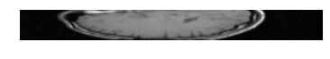

```python
       #display the image slice in the middle of the stack, x axis

x = mr_image.GetWidth()/2

npa_xslice = npa[:,:,x]
plt.imshow(npa_xslice, cmap=plt.cm.Greys_r)
plt.axis('off')

print('Image spacing: {0}'.format(mr_image.GetSpacing()))
```

```
Image spacing: (1.25, 1.25)
```

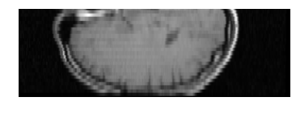

```python
     # Collapse along the x axis
extractSliceFilter = sitk.ExtractImageFilter()
size = list(mr_image.GetSize())
size[0] = 0
extractSliceFilter.SetSize( size )

index = (x, 0, 0)
extractSliceFilter.SetIndex(index)
sitk_xslice = extractSliceFilter.Execute(mr_image)

    # Resample slice to isotropic
original_spacing = sitk_xslice.GetSpacing()
original_size = sitk_xslice.GetSize()

min_spacing = min(sitk_xslice.GetSpacing())
new_spacing = [min_spacing, min_spacing]
new_size = [int(round(original_size[0]*(original_spacing[0]/min_spacing))),
            int(round(original_size[1]*(original_spacing[1]/min_spacing)))]
resampleSliceFilter = sitk.ResampleImageFilter()

      # Why is the image pixelated?
sitk_isotropic_xslice = resampleSliceFilter.Execute(sitk_xslice, new_size, sitk.Transform(), sitk.sitkNearestNeighbor, sitk_xslice.GetOrigin(),
                                                    new_spacing, sitk_xslice.GetDirection(), 0, sitk_xslice.GetPixelIDValue())

plt.imshow(sitk.GetArrayFromImage(sitk_isotropic_xslice), cmap=plt.cm.Greys_r)
plt.axis('off')
print('Image spacing: {0}'.format(sitk_isotropic_xslice.GetSpacing()))
```

So if you really want to look at your images, use the sitk.Show command:

```python
try:
    sitk.Show(mr_image)
except RuntimeError:
    print('SimpleITK Show method could not find the viewer (ImageJ not installed or ' +
          'environment variable pointing to non existant viewer).')
```

Use a different viewer by setting environment variable(s). Do this from within your ipython notebook using 'magic' functions, or set in a more permanent manner using your OS specific convention.

```python
%env SITK_SHOW_COMMAND /Applications/ITK-SNAP.app/Contents/MacOS/ITK-SNAP

try:
    sitk.Show(mr_image)
except RuntimeError:
    print('SimpleITK Show method could not find the viewer (ImageJ not installed or ' +
          'environment variable pointing to non existant viewer).')
```

```
env: SITK_SHOW_COMMAND=/Applications/ITK-SNAP.app/Contents/MacOS/ITK-SNAP
```

```python
%env SITK_SHOW_COMMAND '/Applications/ImageJ/ImageJ.app/Contents/MacOS/JavaApplicationStub'
try:
    sitk.Show(mr_image)
except RuntimeError:
    print('SimpleITK Show method could not find the viewer (ImageJ not installed or ' +
          'environment variable pointing to non existant viewer).')
```

```
env: SITK_SHOW_COMMAND='/Applications/ImageJ/ImageJ.app/Contents/MacOS/JavaApplicationStub'
```

```python
%env SITK_SHOW_COMMAND '/Applications/Slicer.app/Contents/MacOS/Slicer'
sitk.Show(mr_image)
```

```
env: SITK_SHOW_COMMAND='/Applications/Slicer.app/Contents/MacOS/Slicer'
```